# PDF to HTML

[figure not shown]

STAT 494: STATISTICAL GENETICS  
A COMPARATIVE STUDY ON THE PREDICTIVE  
POWERS OF LASSO, KNN AND SVM IN THE TASK  
OF TUMOR CLASSIFICATION  
Authors: Sam Price, and Tam NguyenNoah Shannon  
Introduction, Motivation, and Data  
Rationale  
In the rapidly evolving field of computational biology, selecting appropriate analytical  
methods is crucial for deriving meaningful insights from increasingly complex datasets.  
Throughout our journal club sessions this semester, we have systematically reviewed  
cutting-edge research applying machine learning approaches to biological data analysis.

These discussions revealed notable patterns in methodological choices that warrant  
further exploration and synthesis.  
Our class has traditionally focused on single nucleotide polymorphism (SNP) data,  
analyzing genetic variations at the most granular level to understand their associations with  
phenotypic traits and disease susceptibility. SNP-level analyses have proven valuable for  
identifying specific genetic markers and have been foundational to genome-wide  
association studies (GWAS). However, they often present significant computational  
challenges, particularly when dealing with high-dimensional data that includes millions of  
variants across thousands of samples.  
In contrast, the paper we reviewed for this project adopted a gene-centric analytical  
approach, effectively "zooming out" from individual nucleotides to examine variation and  
expression at the gene level. This shift in granularity, while sacrificing some fine-detail  
resolution, offers several compelling advantages. Gene-level analyses can potentially  
reduce dimensionality, mitigate multiple testing burdens, improve interpretability through  
direct biological context, and enhance statistical power by aggregating signals across  
multiple variants.  
Data Context  
The data we use for this project provides information on 12534 genes (number of columns)  
belonging to 174 observations (number of rows). Below is a snippet of what it looks like.  
2

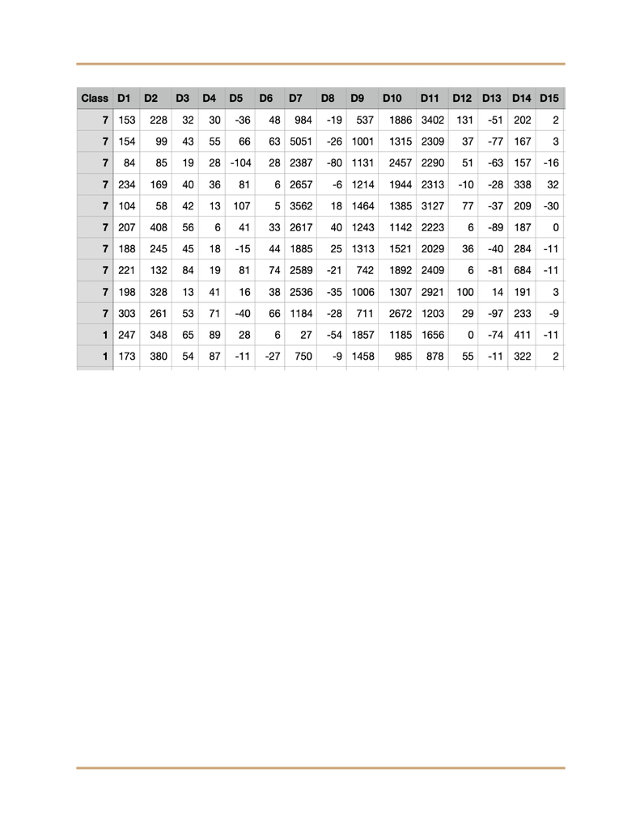

The columns that start with capital letter D represent the genes and the `Class` column  
consists of 11 tumor types we would like to identify. The values under any of the D columns  
indicate how `on` a gene is during protein production. In other words, the larger the value,  
the more actively that gene participates in such process.  
Background Information  
Machine Learning  
Defined most broadly, machine learning is a field concerned with the development and  
application of statistical algorithms that can learn from seen and then generalize onto  
unseen data, performing tasks and quantifying relationships without explicit instructions.  
Machine learning is widely used across almost every industry in the world as a robust tool  
for prediction across regression and classification tasks. Rather than simply fitting a  
regression like we might in a class like Stat 155, a machine learning approach has us split  
the data into ‘train’ and ‘test’ sets. We use the training set to calibrate and ‘tune’ our model,  
then at the very end use the unseen set aside test data as the true measure of  
performance, simulating the application of the model in the real world.  
3

One of the most common challenges faced in machine learning is the ‘curse of  
dimensionality’, which arises when the efficiency and effectiveness of an algorithm or  
model deteriorates as the dimensionality of the data increases, leading to overfitting,  
spurious correlations, and computational complexity. This will be a recurring problem our  
models seek to address in this project.  
Overfitting is an abstract but critical term to understand when building or interpreting  
machine learning models, and it applies to both regression and classification prediction  
tasks. The ‘fit’ of a model, or how the model understands the relationship or shape present  
in the data, can be roughly categorized in three ways:  
1. Underfit: A model is underfit when it is too simple to capture the true relationship  
in the data. As we see in both of the visual examples below, an underfit model might  
ascribe a linear relationship to two variables, when the relationship is more  
complex. Since the model is failing to capture the true complexity of the  
relationship, it is underfit.  
2. Overfit: The opposite of underfit, but also bad! A model is overfit when it mistakes  
random noise or idiosyncrasies in the training data for generalizable aspects of the  
true relationship between the variables. The model clings too closely to the training  
data, creating a force or too good to be true fit that fails to generalize to new data  
with different random noise.  
3. Well-Fit. The goal. A well fit model strikes the balance between under and  
overfitting, capturing the true relationship present in the data while not mistaking  
random noise for true trends. While a well-fit model won’t be initially perfect on the  
training set like an overfit model, it will perform better on unseen data (which is  
where performance matters).  
4

[figure not shown]

However, what happens when we can’t visually verify the fit of our model like we can in the  
2-d figures? In the context of our project (and many others) high dimensional data and  
models make such easy and intuitive observation difficult. Instead, we’ll use comparisons  
between the training and test performance as our metric to avoid overfitting. If our test  
accuracy is meaningfully lower than our training accuracy, it’s good evidence that our  
model is over-adjusting to the training data at the cost of generalizability.  
5

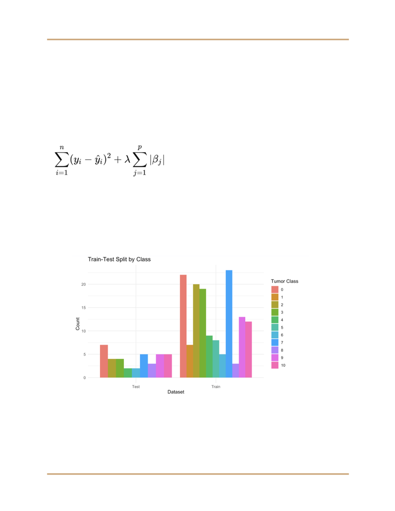

Models  
LASSO  
LASSO is a machine learning algorithm that stands for Least Absolute Shrinkage and  
Selection Operator. It is an ordinary least squares regression with a penalty term called  
lambda. The goal is to minimize the entire function.  
This works by shrinking the coefficients, beta, down towards zero when they don’t  
add much to the regression. This is useful in the context of genetic data because most large  
genetic datasets have more columns than observations, so ordinary least squares cannot  
be run. If coefficients are shrunk to zero that effectively eliminates columns in the data so  
we are left with more observations than variables. In the coming paragraphs we will walk  
through how to run LASSO in r and what some of the lines mean, using our data. This can  
be followed along using the qmd file in the same folder as this README. This framework  
can be applied to any form of data, not just the data we used. We use the test and training  
splits that were used earlier, so that our metrics are being compared accurately.  
6

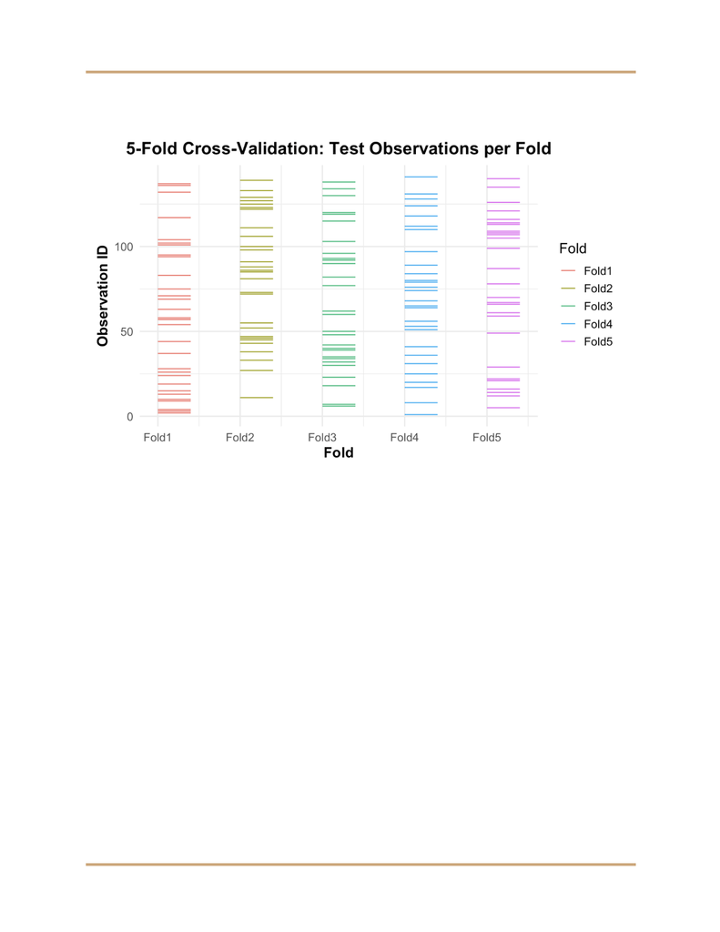

We pull that data in and make all genes numeric and the Class variable a factor for  
both the test and training data. Then we split the data into five folds for cross validation.  
After that we define the model specification for the multinomial LASSO regression.  
This code chunk works by using the multinom_reg() function from the parsnip package,  
with penalty = tune() indicating that the regularization strength will be tuned later during  
model selection. The mixture = 1 parameter sets the regularization to be pure LASSO,  
rather than Ridge Regression or a mix of both. The model is then assigned the glmnet  
engine, which fits regularized generalized linear models. Lastly, set_mode("classification")  
tells parsnip that this is a classification model.  
The lasso rec creates a preprocessing recipe for the modeling workflow. The formula  
Class ~ . specifies that the outcome variable is Class, and all other variables in the dataset  
tumor_train will be used as predictors. Then it standardizes all numeric predictor variables  
by centering them to have a mean of zero and scaling them to have a standard deviation of  
one. This normalization is important for models like LASSO, which are sensitive to the scale  
of the input features. The resulting lasso_rec object defines how the data should be  
preprocessed before being passed to the model during training and evaluation. Then the  
workflow combines the recipe and model so that the data is always prepared the same way  
before being used by the model.  
7

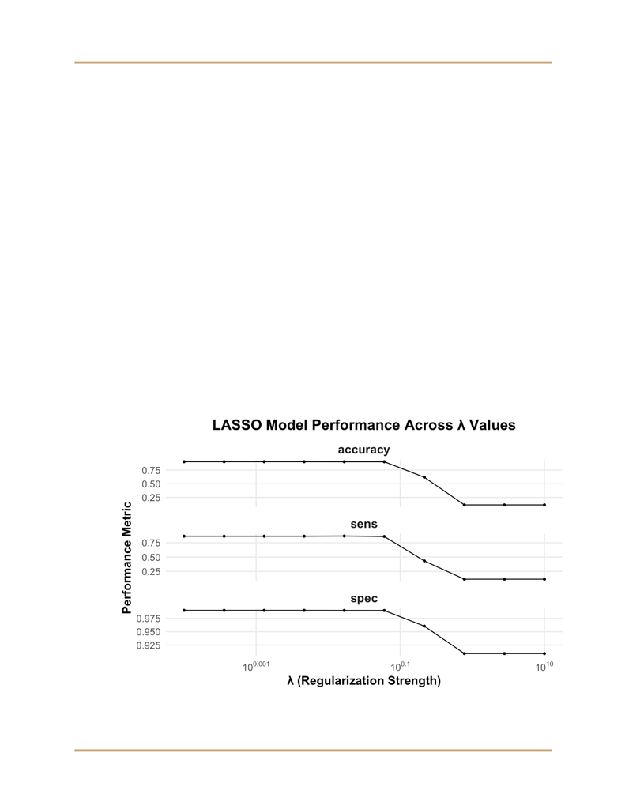

We create a grid of ten lambda values to test how different levels of regularization  
affect the model’s performance. After that we perform hyperparameter tuning by testing  
different values of the regularization parameter (lambda) to find the best-performing  
version of my LASSO model.  
tune_grid(...): Tries out a bunch of different lambda values from penalty_grid, one by  
one, to see which one helps the model perform best. It does that using the workflow  
previously defined and the metrics line says what metrics to look at, while the control line  
saves the results. We then graph these results and put them in a table. The next important  
line of code is selecting the best lambda, which is done with the select by one standard  
error function, which chooses the best lambda based on accuracy. It does this by using the  
tune output data that was previously created, putting them in descending order of  
accuracy, and picking the best lambda within one standard deviation of the actual best  
lambda. We also ran this for sensitivity and found that the penalty term was the same, but  
this may not be the case if this were to be run on other data. Below is a graph of how each  
metric changes as lambda increases. As lambda increases all three metrics stay the same  
and once lambda gets large enough they start to drop off. Showing how as too many  
coefficients get shrunk to zero, the model loses accuracy.  
8

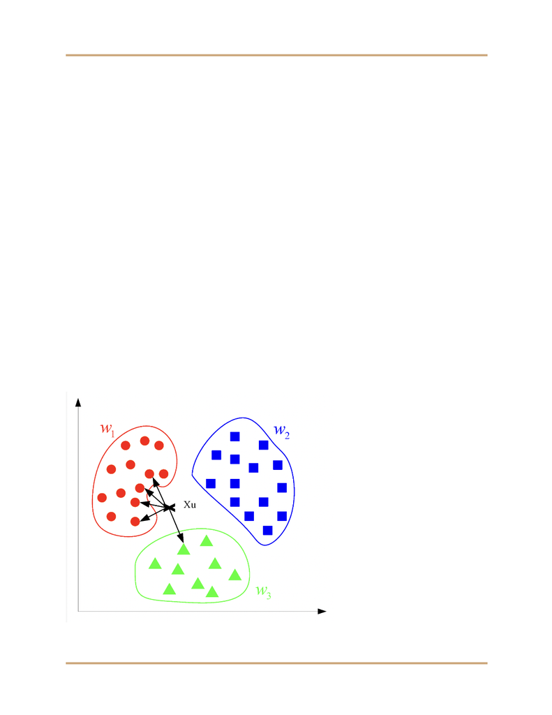

Next we fit the data using finalize workflow, which makes sure to use the best  
lambda on the workflow previously created then fits the data to all of the training data. We  
then make predictions on the test data set. The code bind_cols places each prediction  
alongside the actual class label and all the original features from the test dataset. We also  
do this for the best lambda by sensitivity as a sanity check, to make sure the numbers are  
the same.  
We then take the final fit data and filter out all the coefficients that were not shrunk  
down to zero and do the same form the sensitivity code. In this case we were left with 111  
predictors, cut down from the thousands that were previously in the data. We then make a  
confusion matrix showing how accurate our predictions were. The rest of the code is  
outputting the metrics into a data table.  
KNN  
K-nearest neighbors, or KNN for short, is a classic but powerful machine learning algorithm  
that classifies a data point on the basis of its k nearest neighbors. After a query point is  
selected, a majority vote of the nearest neighbors is used to assign the new point to the  
data class which has the most representatives within the nearest neighbors of the point.  
9

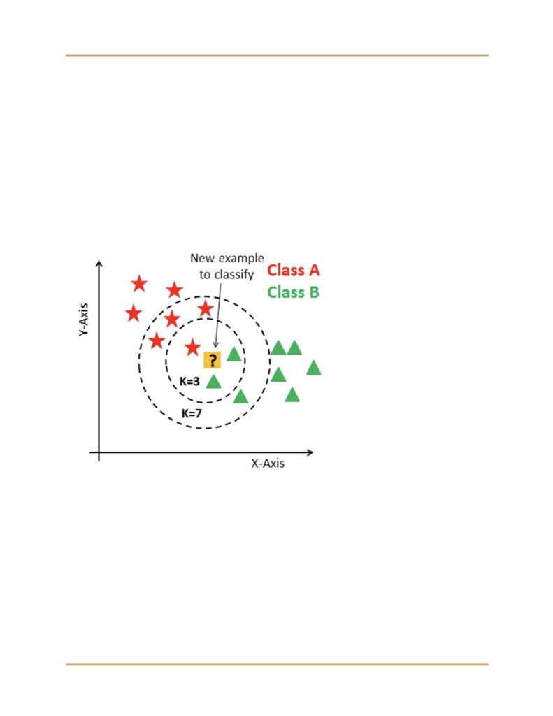

KNN is a powerful algorithm because it is non-parametric, in other words it doesn’t make  
assumptions about the underlying data. While a linear regression model inherently  
assumes a linear relationship, a model like KNN doesn’t, allowing it to capture nuanced  
classification and decision boundaries of complex relationships. KNN is also powerful  
because of its simplicity, including only a few hyperparameters, or adjustable elements of  
the model that can be used to refine performance. While ‘k’, or the number of neighbors  
polled to classify a new point, is the main hyperparameter, one can also experiment with  
the type of distance calculation used to define the ‘nearest’ neighbors in the first place (we  
use classic Euclidean distance).  
The behavior of the model changes as we adjust the number of nearest neighbors we take  
into account, demonstrated by the figure above. If we only use 3 neighbors, we’ll classify  
the query point as a triangle. However, if we use 7, we’ll classify it as a star. In general, the  
fewer neighbors we use, the more volatile and dynamic our model becomes (adjectives  
with positive connotation, but not inherently best in this context!), increasing the variance  
but decreasing the bias. As we use more neighbors, the model becomes slower to adjust,  
decreasing variance but increasing bias.  
10

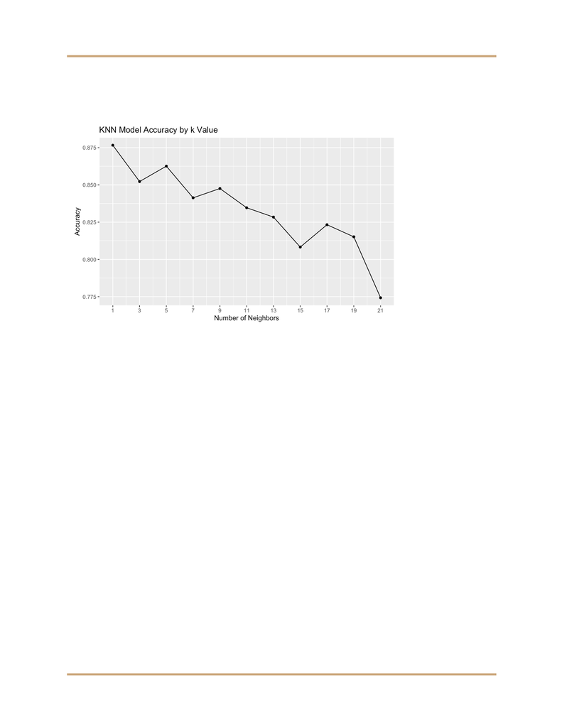

Shown by the plot below, after testing the performance of a variety of k values, using a  
single nearest neighbor yielded the best accuracy for our KNN model.  
This model used two strategies to address the curse of dimensionality, or p > n problem,  
eventually yielding two distinct KNN models. The first was aggressive feature selection,  
narrowing down the genes to only the most 100 predictors. The second was the use of  
Principal Component Analysis, or PCA, as a feature selection tool. PCA attempts to reduce  
the dimensionality of the data while preserving as much information as possible by  
decomposing the predictor variables into linearly independent or orthogonal principal  
components that are then used by the model as predictors. We’ll see how these strategies  
panned out in the results section.  
11

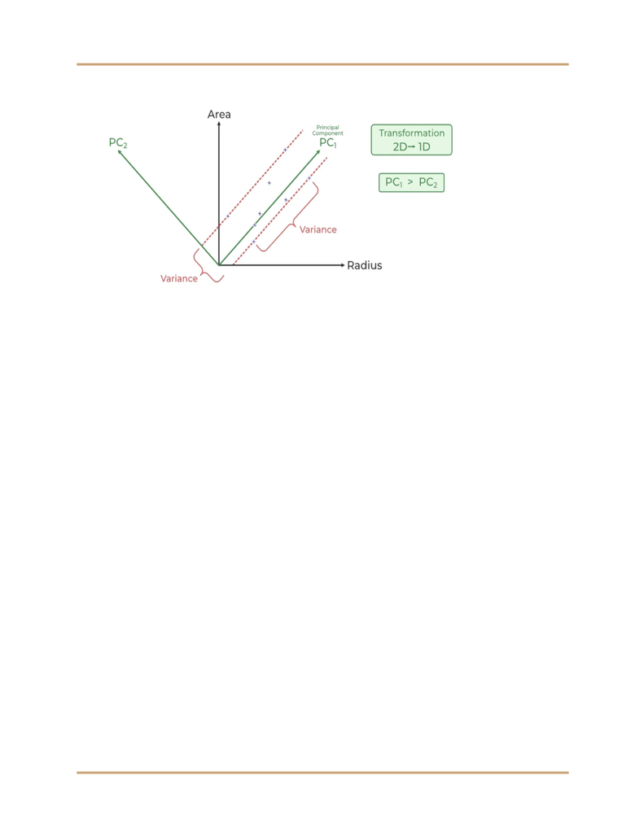

We took a couple of other standard machine learning steps when fitting this model, using  
10-fold cross validation and normalizing feature scales to ensure no single gene dominated  
on the basis of a large numerical range, which ensured the validity of our distance  
measure.  
SVM  
How it works  
The core of support vector machines lie in their power to increase the dimensional space  
our data currently lives in. To illustrate why this is important, here is a little brain teaser  
activity. Given a set of data points, can we find a line that separates the blue circles from  
the red ones?  
12

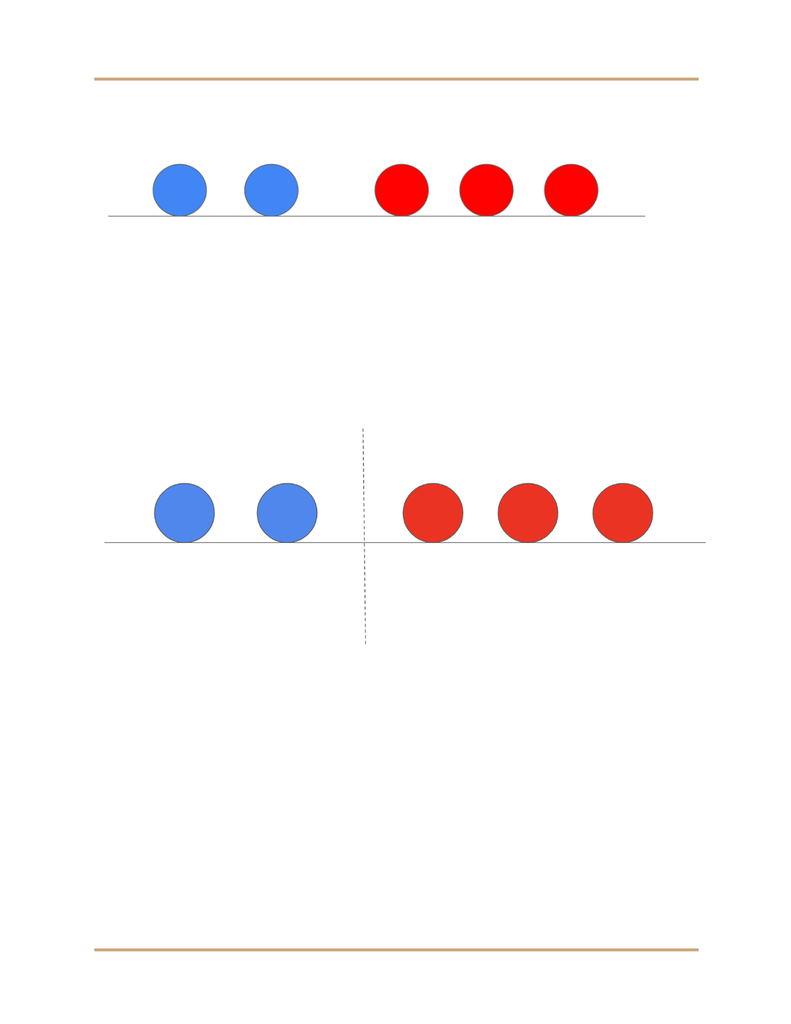

In this particular case, it is rather straightforward to pick as line that groups those circles by  
the color, as is shown below:  
However, real life data tends to be more complicated than the example provided above. In  
fact, let’s consider this next case:  
13

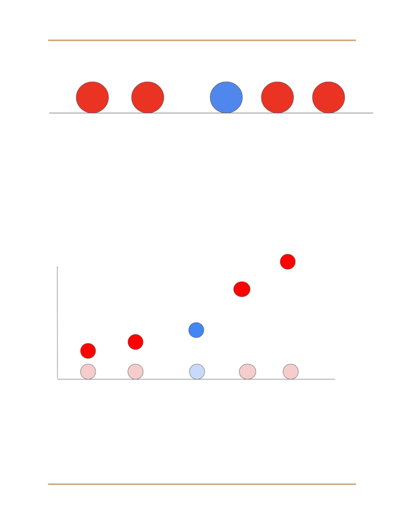

In this scenario, the answer might not be as obvious. As one soon may find out, there does  
not exist a line such that the red and the blue circles are clearly separated. To solve this  
problem, one useful trick is to change how the data points are represented by increasing  
their current dimensional space. Specifically, one can choose to square the values of the  
circles on the x axis (now a 1-dimensional space), effectively converting them to data  
belonging to a new 2-dimensional space.  
After the transformation, the task of finding the best decision boundary becomes slightly  
easier than before. For this very simplified example, such dividing line can be constructed  
as below  
14

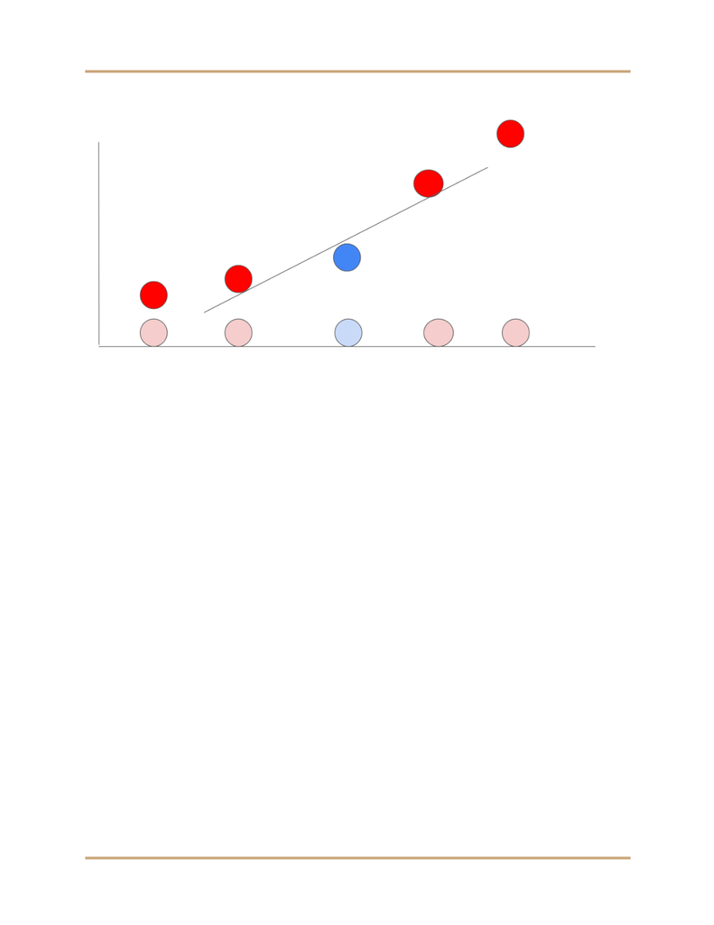

In actuality however, the algorithm does not physically change the data. It only does so  
“abstractly” purely for the purpose of finding the best boundary. Our data therefore  
remains intact.  
Kernel  
The conversion we demonstrated above can be dictated by a hyperparameter required for  
SVM models, called the “kernel”. Some of the most commonly used ones include linear,  
polynomial and radial. The process of squaring data in the previous example is done  
through the “polynomial” kernel. As for the radial kernel , it is particularly useful in dealing  
with highly non-linear data and to understand how it works is no easy task, Radial type is a  
special, more complex case of transformation where data is augmented to some infinite  
dimensional space, so intricate that there is no way to visually illustrate it.  
It is also worth mentioning that as we play with these types of kernels and compare how  
the model performs accordingly, we may derive some useful insights from the linearity of  
the data we are using. For example, after running 3 aforementioned kernel types on the  
tumors dataset, we learned that accuracy decreased the more complex we adjusted our  
model to be  
15

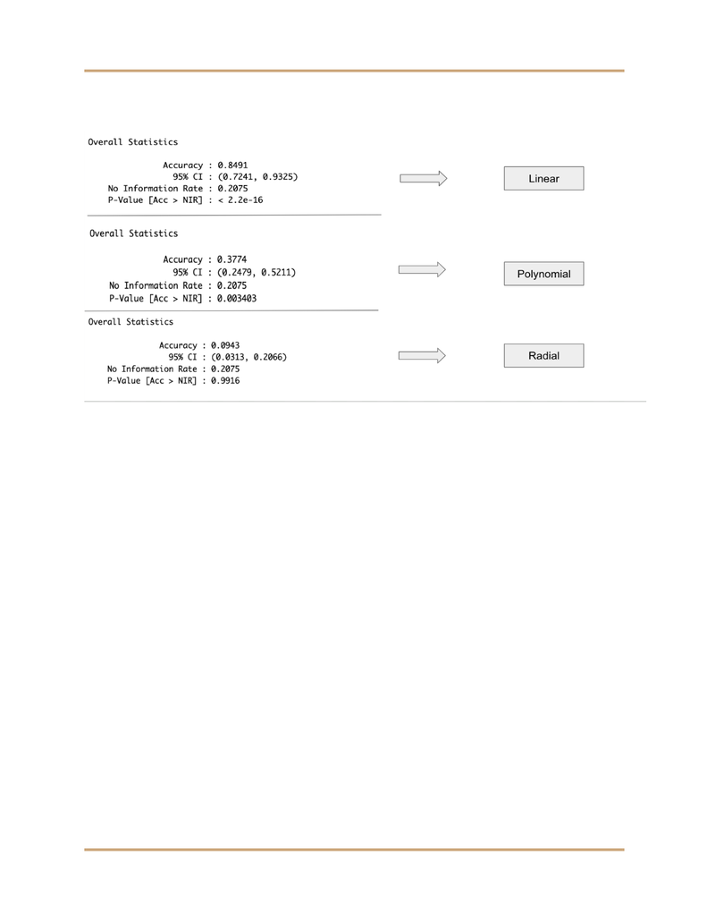

We can see from the image above that the linear version outperformed the other two, with  
the radial classifier underperforming relative to the no-information rate, meaning it  
performs worse than guessing the most frequent class.  
So what can we say about the data? It is linear enough that we only need a linear  
transformation to complete the classification task successfully, without the need to use  
more complicated kernels, which may end up exacerbating the results.  
16

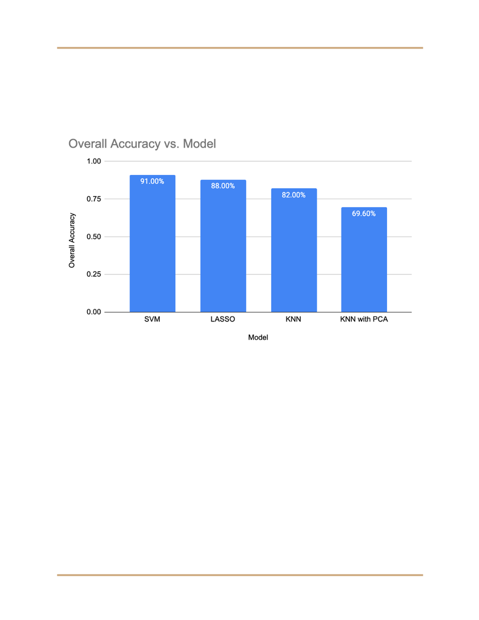

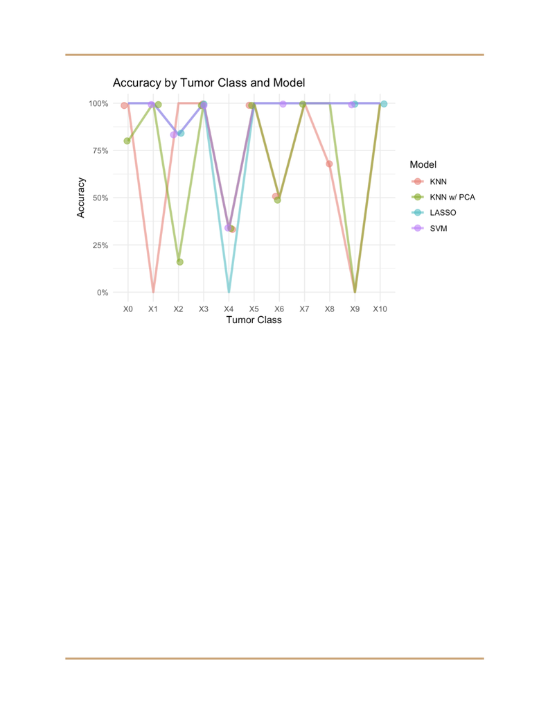

Sensitivity/Specificity  
The final metrics we used were sensitivity and specificity. Sensitivity is the true positive rate  
and specificity is the true negative rate. When predicting a certain class, if we were to  
predict not that class our specificity would still be very high, which is why we care the most  
about sensitivity. We want to find, of the actual positives, how many did we actually predict  
to be positive. We find that KNN and LASSO have nearly identical sensitivities and SVM is  
close behind. KNN with PCA is lower but still has a high enough sensitivity to use if  
necessary. We wouldn’t recommend using a single metric rather a combination of these,  
with the first two choices being KNN and LASSO.  
19

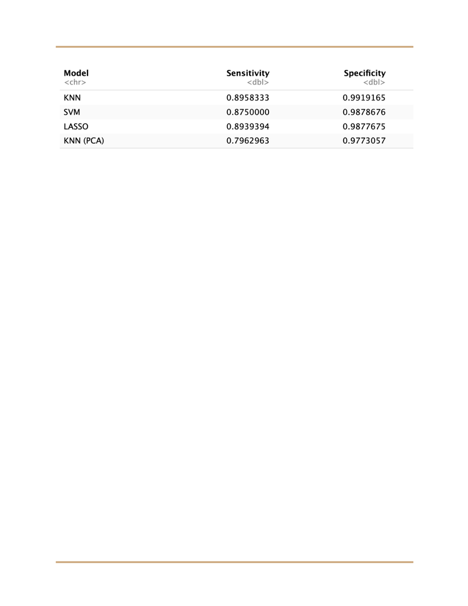

Main Conclusion  
The three models—SVM, LASSO, and KNN (without PCA)—achieved similarly high overall  
accuracies. Among them, SVM demonstrated the best performance in terms of both overall  
and per-class accuracy. While KNN and LASSO occasionally outperformed SVM in metrics  
such as sensitivity and specificity, the differences were minimal, typically within a margin of  
0.01 to 0.02.  
20